# Notes about the SAS's Course

## 0. Script to setup the sesion

Run this script in the begining the each session to access the data in the correct way.

```sas
%let InicioCurso=/folders/myfolders/Statistics1_ANOVA_Regression_LogisticRegression;
%include "&InicioCurso/inicio.sas";
```

[output not shown]

## 7: Categorical Data Analysis

- Logistic regression is used to model the relationship between a binary response variable and a set of predictor variables.
- first look for associations between predictors and a binary response using hypothesis tests.
- build a logistic regression model and discuss how to characterize the relationship between the response and predictors.
- use logistic regression to build a model, or classifier, to predict unknown cases.

#### Associations between Categorical Variables

- you can determine the frequencies of data values and possible associations among variables. An association exists between two categorical variables if the distribution of one variable changes when the value of the other variable changes.
- To look for associations, you examine the frequencies of values across the combinations of variables.

#### Demo: Examining the Distribution of Categorical Variables Using PROC FREQ and PROC UNIVARIATE

The FREQ Procedure

| Sale Price > $175,000 Bonus | Sale Price > $175,000 Frequency | Sale Price > $175,000 Percent | Sale Price > $175,000 Cumulative Frequency | Sale Price > $175,000 Cumulative Percent |
| --- | --- | --- | --- | --- |
| Not Bonus Eligible | 255 | 85.00 | 255 | 85.00 |
| Bonus Eligible | 45 | 15.00 | 300 | 100.00 |

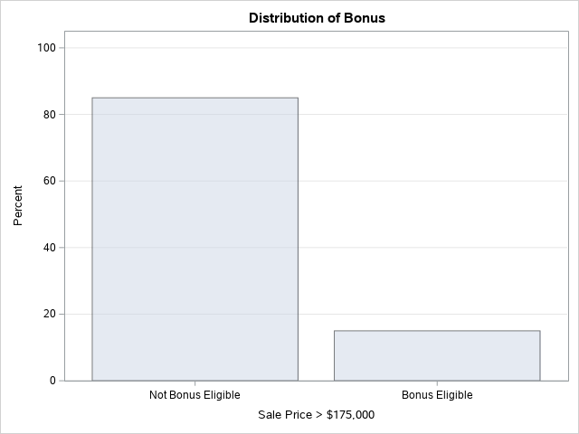

| Number of fireplaces Fireplaces | Number of fireplaces Frequency | Number of fireplaces Percent | Number of fireplaces Cumulative Frequency | Number of fireplaces Cumulative Percent |
| --- | --- | --- | --- | --- |
| 0 | 195 | 65.00 | 195 | 65.00 |
| 1 | 93 | 31.00 | 288 | 96.00 |
| 2 | 12 | 4.00 | 300 | 100.00 |

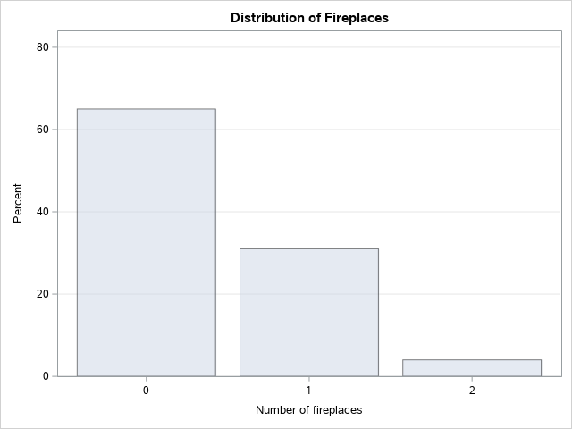

| Regular or irregular lot shape Lot_Shape_2 | Regular or irregular lot shape Frequency | Regular or irregular lot shape Percent | Regular or irregular lot shape Cumulative Frequency | Regular or irregular lot shape Cumulative Percent |
| --- | --- | --- | --- | --- |
| Irregular | 93 | 31.10 | 93 | 31.10 |
| Regular | 206 | 68.90 | 299 | 100.00 |

Frequency Missing = 1

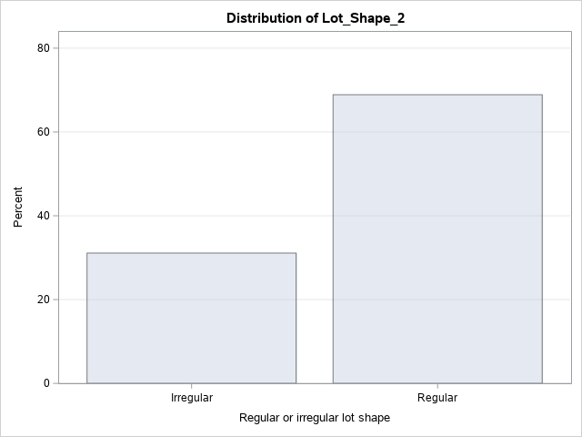

| Frequency Percent Row Pct Col Pct |
| --- |

| Table of Fireplaces by Bonus Fireplaces(Number of fireplaces) | Table of Fireplaces by Bonus Bonus(Sale Price > $175,000) Not Bonus Eligible | Table of Fireplaces by Bonus Bonus(Sale Price > $175,000) Bonus Eligible | Table of Fireplaces by Bonus Bonus(Sale Price > $175,000) Total |
| --- | --- | --- | --- |
| 0 | 177 59.00 90.77 69.41 | 18 6.00 9.23 40.00 | 195 65.00 |
| 1 | 68 22.67 73.12 26.67 | 25 8.33 26.88 55.56 | 93 31.00 |
| 2 | 10 3.33 83.33 3.92 | 2 0.67 16.67 4.44 | 12 4.00 |
| Total | 255 85.00 | 45 15.00 | 300 100.00 |

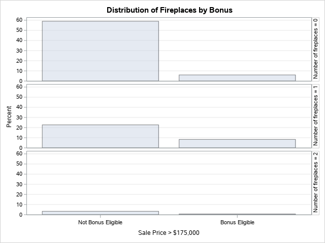

| Frequency Percent Row Pct Col Pct |
| --- |

| Table of Lot_Shape_2 by Bonus Lot_Shape_2(Regular or irregular lot shape) | Table of Lot_Shape_2 by Bonus Bonus(Sale Price > $175,000) Not Bonus Eligible | Table of Lot_Shape_2 by Bonus Bonus(Sale Price > $175,000) Bonus Eligible | Table of Lot_Shape_2 by Bonus Bonus(Sale Price > $175,000) Total |
| --- | --- | --- | --- |
| Irregular | 62 20.74 66.67 24.31 | 31 10.37 33.33 70.45 | 93 31.10 |
| Regular | 193 64.55 93.69 75.69 | 13 4.35 6.31 29.55 | 206 68.90 |
| Total | 255 85.28 | 44 14.72 | 299 100.00 |
| Frequency Missing = 1 |  |  |  |

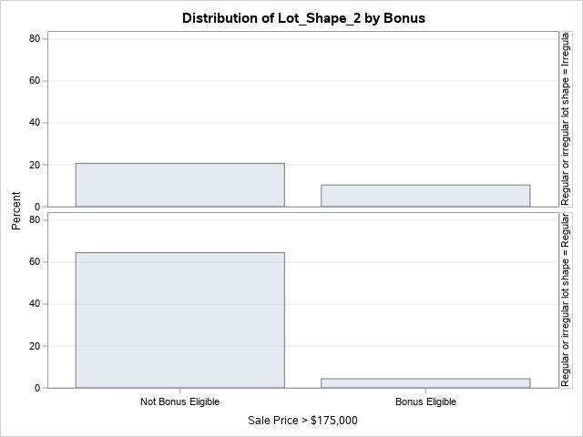

The UNIVARIATE Procedure

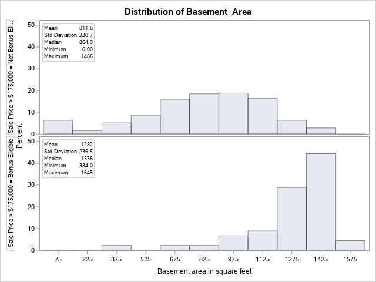

```sas
title;
proc format;
    value bonusfmt 1 = "Bonus Eligible"
                   0 = "Not Bonus Eligible"
                  ;
run;

proc freq data=STAT1.ameshousing3;
    tables Bonus Fireplaces Lot_Shape_2
           Fireplaces*Bonus Lot_Shape_2*Bonus/
           plots(only)=freqplot(scale=percent);
    format Bonus bonusfmt.;
run;

proc univariate data=STAT1.ameshousing3 noprint;
    class Bonus;
    var Basement_Area ;
    histogram Basement_Area;
    inset mean std median min max / format=5.2 position=nw;
    format Bonus bonusfmt.;
run;
```

#### Practice: Using PROC FREQ to Examine Distributions

An insurance company wants to relate the safety of vehicles to several other variables. A score was given to each vehicle model, using the frequency of insurance claims as a basis. The stat1.safety data set contains the data about vehicle safety.

1. Use PROC FREQ to create one-way frequency tables for the categorical variables Unsafe, Type, Region, and Size. Submit the code and view the results.

```sas
ods graphics off;

proc print data=STAT1.safety(obs=3);
run;

proc freq data=STAT1.safety;
   tables Unsafe Type Region Size;
   title "Safety Data Frequencies";
run;
ods graphics on;
```

LOGISTIC MODEL (1):Unsafe=Weight

| Obs | Unsafe | Size | Weight | Region | Type |
| --- | --- | --- | --- | --- | --- |
| 1 | 0 | 2 | 3 | N America | Medium |
| 2 | 0 | 3 | 4 | N America | Sport/Utility |
| 3 | 0 | 2 | 3 | N America | Medium |

Safety Data Frequencies

The FREQ Procedure

| Unsafe | Frequency | Percent | Cumulative Frequency | Cumulative Percent |
| --- | --- | --- | --- | --- |
| 0 | 66 | 68.75 | 66 | 68.75 |
| 1 | 30 | 31.25 | 96 | 100.00 |

| Type | Frequency | Percent | Cumulative Frequency | Cumulative Percent |
| --- | --- | --- | --- | --- |
| Large | 16 | 16.67 | 16 | 16.67 |
| Medium | 29 | 30.21 | 45 | 46.88 |
| Small | 20 | 20.83 | 65 | 67.71 |
| Sport/Utility | 16 | 16.67 | 81 | 84.38 |
| Sports | 15 | 15.63 | 96 | 100.00 |

| Region | Frequency | Percent | Cumulative Frequency | Cumulative Percent |
| --- | --- | --- | --- | --- |
| Asia | 35 | 36.46 | 35 | 36.46 |
| N America | 61 | 63.54 | 96 | 100.00 |

| Size | Frequency | Percent | Cumulative Frequency | Cumulative Percent |
| --- | --- | --- | --- | --- |
| 1 | 35 | 36.46 | 35 | 36.46 |
| 2 | 29 | 30.21 | 64 | 66.67 |
| 3 | 32 | 33.33 | 96 | 100.00 |

1. What is the measurement scale of each of the four variables?

Solution: Unsafe - Nominal, Binary Type - Nominal Region - Nominal Size - Ordinal Weight - Continuous

1. Do the variables Unsafe, Type, Region, and Size have any unusual values that warrant further investigation?

Solution: No

### Tests of Association

...

#### The Pearson Chi-Square Test

...

#### Odds ratios

...

#### Demo: Performing a Pearson Chi-Square Test of Association Using PROC FREQ

- let's run a formal test to determine whether the associations are significant.between the binary response, Bonus, and the categorical predictors,

```sas
ods graphics off;
proc freq data=STAT1.ameshousing3;
    tables (Lot_Shape_2 Fireplaces)*Bonus
          / chisq expected cellchi2 nocol nopercent
            relrisk;
    format Bonus bonusfmt.;
    title 'Associations with Bonus';
run;

ods graphics on;
```

Associations with Bonus

The FREQ Procedure

| Frequency Expected Cell Chi-Square Row Pct |
| --- |

| Table of Lot_Shape_2 by Bonus Lot_Shape_2(Regular or irregular lot shape) | Table of Lot_Shape_2 by Bonus Bonus(Sale Price > $175,000) Not Bonus Eligible | Table of Lot_Shape_2 by Bonus Bonus(Sale Price > $175,000) Bonus Eligible | Table of Lot_Shape_2 by Bonus Bonus(Sale Price > $175,000) Total |
| --- | --- | --- | --- |
| Irregular | 62 79.314 3.7797 66.67 | 31 13.686 21.905 33.33 | 93 |
| Regular | 193 175.69 1.7064 93.69 | 13 30.314 9.8893 6.31 | 206 |
| Total | 255 | 44 | 299 |
| Frequency Missing = 1 |  |  |  |

Statistics for Table of Lot_Shape_2 by Bonus

| Statistic | DF | Value | Prob |
| --- | --- | --- | --- |
| Chi-Square | 1 | 37.2807 | <.0001 |
| Likelihood Ratio Chi-Square | 1 | 34.4226 | <.0001 |
| Continuity Adj. Chi-Square | 1 | 35.1587 | <.0001 |
| Mantel-Haenszel Chi-Square | 1 | 37.1561 | <.0001 |
| Phi Coefficient |  | -0.3531 |  |
| Contingency Coefficient |  | 0.3330 |  |
| Cramer's V |  | -0.3531 |  |

| Fisher's Exact Test |  |
| --- | --- |
| Cell (1,1) Frequency (F) | 62 |
| Left-sided Pr <= F | <.0001 |
| Right-sided Pr >= F | 1.0000 |
| Table Probability (P) | <.0001 |
| Two-sided Pr <= P | <.0001 |

| Odds Ratio and Relative Risks Statistic | Odds Ratio and Relative Risks Value | Odds Ratio and Relative Risks 95% Confidence Limits | Odds Ratio and Relative Risks 95% Confidence Limits |
| --- | --- | --- | --- |
| Odds Ratio | 0.1347 | 0.0664 | 0.2735 |
| Relative Risk (Column 1) | 0.7116 | 0.6137 | 0.8251 |
| Relative Risk (Column 2) | 5.2821 | 2.9002 | 9.6202 |

Sample Size = 299  
Frequency Missing = 1

| Frequency Expected Cell Chi-Square Row Pct |
| --- |

| Table of Fireplaces by Bonus Fireplaces(Number of fireplaces) | Table of Fireplaces by Bonus Bonus(Sale Price > $175,000) Not Bonus Eligible | Table of Fireplaces by Bonus Bonus(Sale Price > $175,000) Bonus Eligible | Table of Fireplaces by Bonus Bonus(Sale Price > $175,000) Total |
| --- | --- | --- | --- |
| 0 | 177 165.75 0.7636 90.77 | 18 29.25 4.3269 9.23 | 195 |
| 1 | 68 79.05 1.5446 73.12 | 25 13.95 8.7529 26.88 | 93 |
| 2 | 10 10.2 0.0039 83.33 | 2 1.8 0.0222 16.67 | 12 |
| Total | 255 | 45 | 300 |

Statistics for Table of Fireplaces by Bonus

| Statistic | DF | Value | Prob |
| --- | --- | --- | --- |
| Chi-Square | 2 | 15.4141 | 0.0004 |
| Likelihood Ratio Chi-Square | 2 | 14.4859 | 0.0007 |
| Mantel-Haenszel Chi-Square | 1 | 10.7458 | 0.0010 |
| Phi Coefficient |  | 0.2267 |  |
| Contingency Coefficient |  | 0.2211 |  |
| Cramer's V |  | 0.2267 |  |

Sample Size = 300

- Chi-Square statistic is less than .0001, you reject the null hypothesis at the 0.05 level and conclude that there is evidence of an association between Lot_Shape_2 and Bonus.
- The Cramer's V value of -0.3531 indicates that the association detected with the chi-square test is relatively weak.
- the odds ratio, refer to the crosstabulation table at the beginning of the output. The top row (Irregular) is the numerator of the ratio, while the bottom row (Regular) is the denominator. The interpretation is stated in relation to the left column of the crosstabulation table (Not Bonus Eligible).
- The value of 0.1347 says that an irregular lot has about 13.5% of the odds of not being bonus eligible, compared with a regular lot. This is equivalent to saying that a regular lot has about 13.5% of the odds of being bonus eligible, compared with an irregular lot. We can interpret the reciprocal of the odds ratio, 1/0.1347=7.423 similarly. The odds of being bonus eligible are more than seven times the odds for homes with irregular lot shapes than regular lot shapes.

#### The Mantel-Haenszel Chi-Square Test

- For ordinal associations, the Mantel-Haenszel chi-square test is a more powerful test than the Pearson chi-square test.
- When two variables have an ordinal association, an increase in the value of one variable tends to be associated with an increase or decrease in the value of the other variable.

#### Demo: Detecting Ordinal Associations Using PROC FREQ

we use PROC FREQ to test whether an ordinal association exists between Bonus and Fireplaces.

```sas
ods graphics off;
proc freq data=STAT1.ameshousing3;
    tables Fireplaces*Bonus / chisq measures cl;
    format Bonus bonusfmt.;
    title 'Ordinal Association between FIREPLACES and BONUS?';
run;

ods graphics on;
```

Ordinal Association between FIREPLACES and BONUS?

The FREQ Procedure

| Frequency Percent Row Pct Col Pct |
| --- |

| Table of Fireplaces by Bonus Fireplaces(Number of fireplaces) | Table of Fireplaces by Bonus Bonus(Sale Price > $175,000) Not Bonus Eligible | Table of Fireplaces by Bonus Bonus(Sale Price > $175,000) Bonus Eligible | Table of Fireplaces by Bonus Bonus(Sale Price > $175,000) Total |
| --- | --- | --- | --- |
| 0 | 177 59.00 90.77 69.41 | 18 6.00 9.23 40.00 | 195 65.00 |
| 1 | 68 22.67 73.12 26.67 | 25 8.33 26.88 55.56 | 93 31.00 |
| 2 | 10 3.33 83.33 3.92 | 2 0.67 16.67 4.44 | 12 4.00 |
| Total | 255 85.00 | 45 15.00 | 300 100.00 |

Statistics for Table of Fireplaces by Bonus

| Statistic | DF | Value | Prob |
| --- | --- | --- | --- |
| Chi-Square | 2 | 15.4141 | 0.0004 |
| Likelihood Ratio Chi-Square | 2 | 14.4859 | 0.0007 |
| Mantel-Haenszel Chi-Square | 1 | 10.7458 | 0.0010 |
| Phi Coefficient |  | 0.2267 |  |
| Contingency Coefficient |  | 0.2211 |  |
| Cramer's V |  | 0.2267 |  |

| Statistic | Value | ASE | 95% Confidence Limits |  |
| --- | --- | --- | --- | --- |
| Gamma | 0.4964 | 0.1111 | 0.2786 | 0.7143 |
| Kendall's Tau-b | 0.2072 | 0.0585 | 0.0926 | 0.3218 |
| Stuart's Tau-c | 0.1449 | 0.0433 | 0.0600 | 0.2298 |
| Somers' D C\|R | 0.1510 | 0.0451 | 0.0626 | 0.2395 |
| Somers' D R\|C | 0.2842 | 0.0786 | 0.1301 | 0.4383 |
| Pearson Correlation | 0.1896 | 0.0591 | 0.0737 | 0.3054 |
| Spearman Correlation | 0.2107 | 0.0594 | 0.0943 | 0.3272 |
| Lambda Asymmetric C\|R | 0.0000 | 0.0000 | 0.0000 | 0.0000 |
| Lambda Asymmetric R\|C | 0.0667 | 0.0603 | 0.0000 | 0.1849 |
| Lambda Symmetric | 0.0467 | 0.0424 | 0.0000 | 0.1298 |
| Uncertainty Coefficient C\|R | 0.0571 | 0.0298 | 0.0000 | 0.1156 |
| Uncertainty Coefficient R\|C | 0.0313 | 0.0167 | 0.0000 | 0.0640 |
| Uncertainty Coefficient Symmetric | 0.0404 | 0.0213 | 0.0000 | 0.0823 |

Sample Size = 300

- The Mantel-Haenszel Chi-Square suggest an odinal association between Bonus and Fireplaces.

#### Practice: Using PROC FREQ to Perform Tests and Measures of Association

The insurance company wants to determine whether a vehicle's safety score is associated with either the region in which it was manufactured or the vehicle's size. The stat1.safety data set contains the data about vehicle safety.

1. Use PROC FREQ to create the crosstabulation of the variables Region by Unsafe. Along with the default output, generate the expected frequencies, the chi-square test of association, and the odds ratio. To clearly identify the values of Unsafe, create and apply a temporary format. Submit the code and view the results.

```sas
proc format;
   value safefmt 0='Average or Above'
                 1='Below Average';
run;

proc freq data=STAT1.safety;
   tables Region*Unsafe / expected chisq relrisk;
   format Unsafe safefmt.;
   title "Association between Unsafe and Region";
run;
```

Association between Unsafe and Region

The FREQ Procedure

| Frequency Expected Percent Row Pct Col Pct |
| --- |

| Table of Region by Unsafe Region | Table of Region by Unsafe Unsafe Average or Above | Table of Region by Unsafe Unsafe Below Average | Table of Region by Unsafe Unsafe Total |
| --- | --- | --- | --- |
| Asia | 20 24.063 20.83 57.14 30.30 | 15 10.938 15.63 42.86 50.00 | 35 36.46 |
| N America | 46 41.938 47.92 75.41 69.70 | 15 19.063 15.63 24.59 50.00 | 61 63.54 |
| Total | 66 68.75 | 30 31.25 | 96 100.00 |

Statistics for Table of Region by Unsafe

| Statistic | DF | Value | Prob |
| --- | --- | --- | --- |
| Chi-Square | 1 | 3.4541 | 0.0631 |
| Likelihood Ratio Chi-Square | 1 | 3.3949 | 0.0654 |
| Continuity Adj. Chi-Square | 1 | 2.6562 | 0.1031 |
| Mantel-Haenszel Chi-Square | 1 | 3.4181 | 0.0645 |
| Phi Coefficient |  | -0.1897 |  |
| Contingency Coefficient |  | 0.1864 |  |
| Cramer's V |  | -0.1897 |  |

| Fisher's Exact Test |  |
| --- | --- |
| Cell (1,1) Frequency (F) | 20 |
| Left-sided Pr <= F | 0.0525 |
| Right-sided Pr >= F | 0.9809 |
| Table Probability (P) | 0.0334 |
| Two-sided Pr <= P | 0.0718 |

| Odds Ratio and Relative Risks Statistic | Odds Ratio and Relative Risks Value | Odds Ratio and Relative Risks 95% Confidence Limits | Odds Ratio and Relative Risks 95% Confidence Limits |
| --- | --- | --- | --- |
| Odds Ratio | 0.4348 | 0.1790 | 1.0562 |
| Relative Risk (Column 1) | 0.7578 | 0.5499 | 1.0443 |
| Relative Risk (Column 2) | 1.7429 | 0.9733 | 3.1210 |

Sample Size = 96

1. For the cars made in Asia, what percentage had a Below Average safety score? Solution: Region is a row variable, so look at the Row Pct value in the Below Average cell of the Asia row. Of the cars made in Asia, 42.86% have a Below Average safety score.
2. For the cars with an Average or Above safety score, what percentage was made in North America? Solution: Look at the Col Pct value in the Average or Above cell of the N America row. Of the cars with an Average or Above safety score, 69.70% were made in North America.
3. Do you see a statistically significant (at the 0.05 level) association between Region and Unsafe? Solution: The association is not statistically significant at the 0.05 alpha level. The p-value is 0.0631.
4. What does the odds ratio compare? What does this suggest about the difference in odds between Asian and North American cars? Solution: The odds ratio compares the odds of Below Average safety for North America versus Asia. The odds ratio of 0.4348 means that cars made in North America have 56.52% lower odds for being unsafe than cars made in Asia.

Note: Recall that the odds ratios in the Estimates of Relative Risk table **are calculated by comparing row1/row2 for column1**. In this problem, this comparison is Asia to N America and the outcome is Average or Above in safety. The value 0.4348 is interpreted as the odds of an Average or Above car made in Asia is 0.4348 times the odds for American-made cars. If you want to compare N America to Asia, still using Average or Above for safety, the odds ratio would be the inverse of 0.4348, or approximately 2.3. This is interpreted as cars made in North America have 2.3 times the odds for being safe than cars made in Asia. This single inversion would also create the odds ratio for comparing Asia to N America but Below Average in safety. If you want to compare N America to Asia using Below Average in safety, you invert your odds ratio twice and return to the value 0.4348.

1. Write another PROC FREQ step to create the crosstabulation of the variables Size and Unsafe. Along with the default output, generate the measures of ordinal association. Format the values of Unsafe. Submit the code and view the results.

```sas
proc freq data=STAT1.safety;
   tables Size*Unsafe / chisq measures cl;
   format Unsafe safefmt.;
   title "Association between Unsafe and Size";
run;
```

Association between Unsafe and Size

The FREQ Procedure

| Frequency Percent Row Pct Col Pct |
| --- |

| Table of Size by Unsafe Size | Table of Size by Unsafe Unsafe Average or Above | Table of Size by Unsafe Unsafe Below Average | Table of Size by Unsafe Unsafe Total |
| --- | --- | --- | --- |
| 1 | 12 12.50 34.29 18.18 | 23 23.96 65.71 76.67 | 35 36.46 |
| 2 | 24 25.00 82.76 36.36 | 5 5.21 17.24 16.67 | 29 30.21 |
| 3 | 30 31.25 93.75 45.45 | 2 2.08 6.25 6.67 | 32 33.33 |
| Total | 66 68.75 | 30 31.25 | 96 100.00 |

Statistics for Table of Size by Unsafe

| Statistic | DF | Value | Prob |
| --- | --- | --- | --- |
| Chi-Square | 2 | 31.3081 | <.0001 |
| Likelihood Ratio Chi-Square | 2 | 32.6199 | <.0001 |
| Mantel-Haenszel Chi-Square | 1 | 27.7098 | <.0001 |
| Phi Coefficient |  | 0.5711 |  |
| Contingency Coefficient |  | 0.4959 |  |
| Cramer's V |  | 0.5711 |  |

| Statistic | Value | ASE | 95% Confidence Limits |  |
| --- | --- | --- | --- | --- |
| Gamma | -0.8268 | 0.0796 | -0.9829 | -0.6707 |
| Kendall's Tau-b | -0.5116 | 0.0726 | -0.6540 | -0.3693 |
| Stuart's Tau-c | -0.5469 | 0.0866 | -0.7166 | -0.3771 |
| Somers' D C\|R | -0.4114 | 0.0660 | -0.5408 | -0.2819 |
| Somers' D R\|C | -0.6364 | 0.0860 | -0.8049 | -0.4678 |
| Pearson Correlation | -0.5401 | 0.0764 | -0.6899 | -0.3903 |
| Spearman Correlation | -0.5425 | 0.0769 | -0.6932 | -0.3917 |
| Lambda Asymmetric C\|R | 0.3667 | 0.1569 | 0.0591 | 0.6743 |
| Lambda Asymmetric R\|C | 0.2951 | 0.0892 | 0.1203 | 0.4699 |
| Lambda Symmetric | 0.3187 | 0.0970 | 0.1286 | 0.5088 |
| Uncertainty Coefficient C\|R | 0.2735 | 0.0836 | 0.1096 | 0.4374 |
| Uncertainty Coefficient R\|C | 0.1551 | 0.0490 | 0.0590 | 0.2512 |
| Uncertainty Coefficient Symmetric | 0.1979 | 0.0615 | 0.0773 | 0.3186 |

Sample Size = 96

1. What statistic do you use to detect an ordinal association between Size and Unsafe? Solution: The Mantel-Haenszel chi-square detects an ordinal association.
2. Do you reject or fail to reject the null hypothesis at the 0.05 level? Solution: You reject the null hypothesis at the 0.05 level.
3. What is the strength of the ordinal association between Size and Unsafe? Solution: The Spearman Correlation is -0.5425.
4. What is the 95% confidence interval around the statistic that measures the strength of the ordinal association? Solution: The confidence interval is (-0.6932, -0.3917).

### Introduction to Logistic Regression

- model the relationship between a binary response and a set of predictor variables.

#### Modeling a Binary Response

- the mean of the response is the probability of a success.
- we want to model the probability of both levels of the response.
- for binary data, the mean of the response is the probability of a success.
- we want to model the probability of both levels of the response.

#### Demo: Fitting a Binary Logistic Regression Model Using PROC LOGISTIC

Let's fit a binary logistic regression model in PROC LOGISTIC to characterize the relationship between the continuous variable Basement_Area and our categorical response, Bonus.

LOGISTIC MODEL (1):Bonus=Basement_Area

The LOGISTIC Procedure

| Model Information |  |  |
| --- | --- | --- |
| Data Set | STAT1.AMESHOUSING3 |  |
| Response Variable | Bonus | Sale Price > $175,000 |
| Number of Response Levels | 2 |  |
| Model | binary logit |  |
| Optimization Technique | Fisher's scoring |  |

| Number of Observations Read | 300 |
| --- | --- |
| Number of Observations Used | 300 |

| Response Profile Ordered Value | Response Profile Bonus | Response Profile Total Frequency |
| --- | --- | --- |
| 1 | 0 | 255 |
| 2 | 1 | 45 |

Probability modeled is Bonus='1'.

| Model Convergence Status |
| --- |
| Convergence criterion (GCONV=1E-8) satisfied. |

| Model Fit Statistics Criterion | Model Fit Statistics Intercept Only | Model Fit Statistics Intercept and Covariates |
| --- | --- | --- |
| AIC | 255.625 | 161.838 |
| SC | 259.329 | 169.246 |
| -2 Log L | 253.625 | 157.838 |

| Testing Global Null Hypothesis: BETA=0 Test | Testing Global Null Hypothesis: BETA=0 Chi-Square | Testing Global Null Hypothesis: BETA=0 DF | Testing Global Null Hypothesis: BETA=0 Pr > ChiSq |
| --- | --- | --- | --- |
| Likelihood Ratio | 95.7870 | 1 | <.0001 |
| Score | 65.5624 | 1 | <.0001 |
| Wald | 48.0617 | 1 | <.0001 |

| Analysis of Maximum Likelihood Estimates Parameter | Analysis of Maximum Likelihood Estimates DF | Analysis of Maximum Likelihood Estimates Estimate | Analysis of Maximum Likelihood Estimates Standard Error | Analysis of Maximum Likelihood Estimates Wald Chi-Square | Analysis of Maximum Likelihood Estimates Pr > ChiSq |
| --- | --- | --- | --- | --- | --- |
| Intercept | 1 | -9.7854 | 1.2896 | 57.5758 | <.0001 |
| Basement_Area | 1 | 0.00739 | 0.00107 | 48.0617 | <.0001 |

| Association of Predicted Probabilities and Observed Responses |  |  |  |
| --- | --- | --- | --- |
| Percent Concordant | 89.5 | Somers' D | 0.791 |
| Percent Discordant | 10.4 | Gamma | 0.792 |
| Percent Tied | 0.1 | Tau-a | 0.202 |
| Pairs | 11475 | c | 0.896 |

| Odds Ratio Estimates and Profile-Likelihood Confidence Intervals Effect | Odds Ratio Estimates and Profile-Likelihood Confidence Intervals Unit | Odds Ratio Estimates and Profile-Likelihood Confidence Intervals Estimate | Odds Ratio Estimates and Profile-Likelihood Confidence Intervals 95% Confidence Limits | Odds Ratio Estimates and Profile-Likelihood Confidence Intervals 95% Confidence Limits |
| --- | --- | --- | --- | --- |
| Basement_Area | 1.0000 | 1.007 | 1.005 | 1.010 |

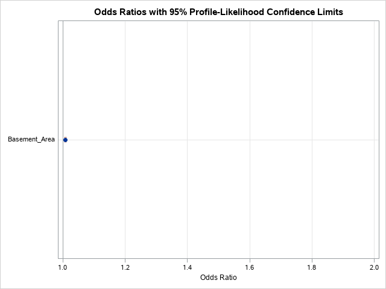

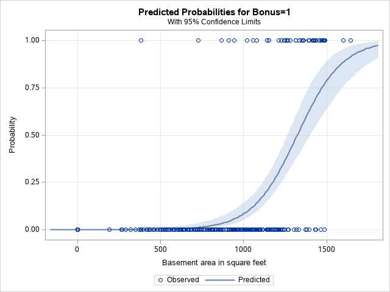

```sas
ods graphics on;
proc logistic data=STAT1.ameshousing3 alpha=0.05
              plots(only)=(effect oddsratio);
    model Bonus(event='1')=Basement_Area / clodds=pl; /*event='1' bonus elegible home*/
    title 'LOGISTIC MODEL (1):Bonus=Basement_Area';
run;
```

- The `PLOTS=` option requests only the EFFECT and ODDSRATIO plots.
- The `ALPHA=` option requests confidence intervals for each parameter estimate.
- The response variable Bonus, and in parentheses, `EVENT=` specifies the event category for the binary response. PROC LOGISTIC then models the probability of the event category you specify.
- use the `CLODDS=` to compute confidence intervals for the odds ratios of all predictor variables. `PL` for profile likelihood, `WALD`, or `BOTH`.
- Profile-likelihood confidence intervals are desirable for small sample sizes.
- The `CLODDS=` option also enables the production of the odds ratio plot that's specified in the PLOTS= option.

**Conclustions**

- Always check to see that the convergence criterion is satisfied.
- The AIC, SC, and -2 Log L are goodness-of-fit measures. These statistics measure relative fit and are used only to compare models. They do not measure absolute fit of any single model. Smaller values for all these measures indicate better fit. However, -2 Log L can be reduced by simply adding more regression parameters to the model. Therefore, it's not used to compare the fit of models that use different numbers of parameters except for comparisons of nested models using likelihood ratio tests. AIC adjusts for the number of predictor variables, and SC adjusts for the number of predictor variables and the number of observations. SC uses a bigger penalty for extra variables, and therefore, favors more parsimonious models.
- The Global Tests table, Testing Global Null Hypothesis: BETA=0, provides three statistics to test the null hypothesis that all regression coefficients of the model are 0. A significant pvalue for these tests provides evidence that at least one of the regression coefficients for a predictor variable is significantly different from 0.
- The Parameter Estimates table, Analysis of Maximum Likelihood Estimates, lists the estimated model parameters, their standard errors, Wald Chi-Square values, and p-values. The parameter estimates are the estimated coefficients of the fitted logistic regression model. For this example, the logistic regression equation is logit(p-hat) = -9.7854 (0.00739) * Basement_Area.
- The Wald Chi-Square and its associated p-value tests whether the parameter estimate is significantly different from 0. The p-value for the variable Basement_Area is significant at the 0.05 alpha level.
- The estimated model is displayed on the probability scale in the effect plot. You can see the sigmoidal shape of the estimated probability curve and that the probability of being bonus eligible increases as the basement area increases.

#### Interpreting the Odds Ratio

...

#### Comparing Pairs to Assess the Fit of a Logistic Regression Model

...

- In general, higher percentages of concordant pairs and lower percentages of discordant and tied pairs indicate a more desirable model.

#### Practice: Using PROC LOGISTIC to Perform a Binary Logistic Regression Analysis

The insurance company wants to characterize the relationship between a vehicle's weight and its safety rating. The stat1.safety data set contains the data about vehicle safety.

1. Use PROC LOGISTIC to fit a simple logistic regression model with Unsafe as the response variable and Weight as the predictor variable. Use the EVENT= option to model the probability of Below Average safety scores. Request profile likelihood confidence limits, an odds ratio plot, and an effect plot. Submit the code and view the results.

LOGISTIC MODEL (1):Unsafe=Weight

The LOGISTIC Procedure

| Model Information |  |
| --- | --- |
| Data Set | STAT1.SAFETY |
| Response Variable | Unsafe |
| Number of Response Levels | 2 |
| Model | binary logit |
| Optimization Technique | Fisher's scoring |

| Number of Observations Read | 96 |
| --- | --- |
| Number of Observations Used | 96 |

| Response Profile Ordered Value | Response Profile Unsafe | Response Profile Total Frequency |
| --- | --- | --- |
| 1 | 0 | 66 |
| 2 | 1 | 30 |

Probability modeled is Unsafe=1.

| Model Convergence Status |
| --- |
| Convergence criterion (GCONV=1E-8) satisfied. |

| Model Fit Statistics Criterion | Model Fit Statistics Intercept Only | Model Fit Statistics Intercept and Covariates |
| --- | --- | --- |
| AIC | 121.249 | 106.764 |
| SC | 123.813 | 111.893 |
| -2 Log L | 119.249 | 102.764 |

| Testing Global Null Hypothesis: BETA=0 Test | Testing Global Null Hypothesis: BETA=0 Chi-Square | Testing Global Null Hypothesis: BETA=0 DF | Testing Global Null Hypothesis: BETA=0 Pr > ChiSq |
| --- | --- | --- | --- |
| Likelihood Ratio | 16.4845 | 1 | <.0001 |
| Score | 13.7699 | 1 | 0.0002 |
| Wald | 11.5221 | 1 | 0.0007 |

| Analysis of Maximum Likelihood Estimates Parameter | Analysis of Maximum Likelihood Estimates DF | Analysis of Maximum Likelihood Estimates Estimate | Analysis of Maximum Likelihood Estimates Standard Error | Analysis of Maximum Likelihood Estimates Wald Chi-Square | Analysis of Maximum Likelihood Estimates Pr > ChiSq |
| --- | --- | --- | --- | --- | --- |
| Intercept | 1 | 3.5422 | 1.2601 | 7.9023 | 0.0049 |
| Weight | 1 | -1.3901 | 0.4095 | 11.5221 | 0.0007 |

| Association of Predicted Probabilities and Observed Responses |  |  |  |
| --- | --- | --- | --- |
| Percent Concordant | 55.2 | Somers' D | 0.474 |
| Percent Discordant | 7.7 | Gamma | 0.754 |
| Percent Tied | 37.1 | Tau-a | 0.206 |
| Pairs | 1980 | c | 0.737 |

| Odds Ratio Estimates and Profile-Likelihood Confidence Intervals Effect | Odds Ratio Estimates and Profile-Likelihood Confidence Intervals Unit | Odds Ratio Estimates and Profile-Likelihood Confidence Intervals Estimate | Odds Ratio Estimates and Profile-Likelihood Confidence Intervals 95% Confidence Limits | Odds Ratio Estimates and Profile-Likelihood Confidence Intervals 95% Confidence Limits |
| --- | --- | --- | --- | --- |
| Weight | 1.0000 | 0.249 | 0.102 | 0.517 |

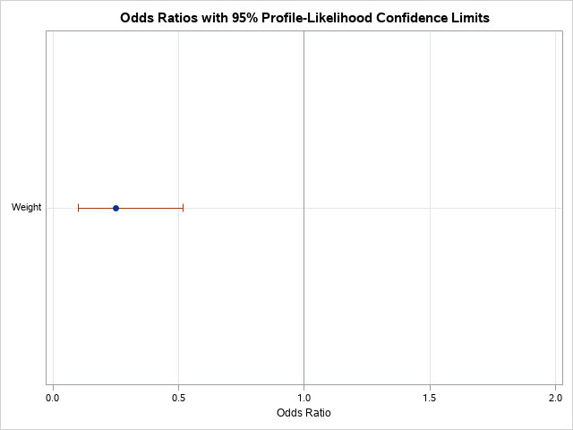

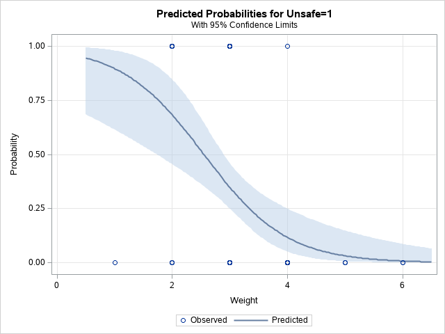

```sas
ods graphics on;
proc logistic data=STAT1.safety plots(only)=(effect oddsratio);
   model Unsafe(event='1')=Weight / clodds=pl;
   title 'LOGISTIC MODEL (1):Unsafe=Weight';
run;
```

1. Do you reject or fail to reject the null hypothesis that all regression coefficients of the model are 0? Solution: The p-value for the Likelihood Ratio test is <.0001, and therefore, the global null hypothesis is rejected.
2. Write the logistic regression equation. Solution:The regression equation is as follows: Logit(Unsafe) = 3.5422 + (-1.3901) * Weight
3. Interpret the odds ratio for Weight. Solution: The odds ratio for Weight (0.249) says that the odds for being unsafe (having a Below Average safety rating) are 75.1% lower for each thousand-pound increase in weight. The confidence interval (0.102 , 0.517) does not contain 1,which indicates that the odds ratio is statistically significant.

#### Logistic Regression with Categorical Predictors

- we can also include several predictors, both continuous and categorical, into our logistic regression model.
- we want to consider a more complex model with many possible predictors to model the relationship jointly, and account for possible interactions between the effects.

#### Specifying a Parameterization Method

- PROC LOGISTIC does not work directly with the categorical predictor variables in the CLASS statement.
- PROC LOGISTIC uses the design variables, and not the original variables, in model calculations.
- There are various methods of parameterizing the classification variables.
- Understanding the parameterization method will help you to interpret your results accurately.
- Effect coding is also known as deviation from the mean coding.
- It compares the effect of each level of the variable to the average effect of all levels.
- β0 is the average value of the logit across all income levels.
- β1 is the difference between the logit for income level 1, or low income, and the average logit across all income levels.
- β2 is the difference between the logit for income level 2, or medium income, and the average logit across all income levels.

#### Demo: Fitting a Multiple Logistic Regression Model with Categorical Predictors Using PROC LOGISTIC

we'll fit a multiple logistic regression model that characterizes the relationship between the response Bonus, and the variables Basement_Area, Lot_Shape_2, and Fireplaces.

LOGISTIC MODEL (2):Bonus= Basement_Area Fireplaces Lot_Shape_2

The LOGISTIC Procedure

| Model Information |  |  |
| --- | --- | --- |
| Data Set | STAT1.AMESHOUSING3 |  |
| Response Variable | Bonus | Sale Price > $175,000 |
| Number of Response Levels | 2 |  |
| Model | binary logit |  |
| Optimization Technique | Fisher's scoring |  |

| Number of Observations Read | 300 |
| --- | --- |
| Number of Observations Used | 299 |

| Response Profile Ordered Value | Response Profile Bonus | Response Profile Total Frequency |
| --- | --- | --- |
| 1 | 0 | 255 |
| 2 | 1 | 44 |

Probability modeled is Bonus='1'.

Note:1 observation was deleted due to missing values for the response or explanatory variables.

| Class Level Information Class | Class Level Information Value | Class Level Information Design Variables | Class Level Information Design Variables |
| --- | --- | --- | --- |
| Fireplaces | 0 | 0 | 0 |
|  | 1 | 1 | 0 |
|  | 2 | 0 | 1 |
| Lot_Shape_2 | Irregular | 1 |  |
|  | Regular | 0 |  |

| Model Convergence Status |
| --- |
| Convergence criterion (GCONV=1E-8) satisfied. |

| Model Fit Statistics Criterion | Model Fit Statistics Intercept Only | Model Fit Statistics Intercept and Covariates |
| --- | --- | --- |
| AIC | 251.812 | 140.499 |
| SC | 255.513 | 159.001 |
| -2 Log L | 249.812 | 130.499 |

| Testing Global Null Hypothesis: BETA=0 Test | Testing Global Null Hypothesis: BETA=0 Chi-Square | Testing Global Null Hypothesis: BETA=0 DF | Testing Global Null Hypothesis: BETA=0 Pr > ChiSq |
| --- | --- | --- | --- |
| Likelihood Ratio | 119.3133 | 4 | <.0001 |
| Score | 91.7250 | 4 | <.0001 |
| Wald | 49.8671 | 4 | <.0001 |

| Type 3 Analysis of Effects Effect | Type 3 Analysis of Effects DF | Type 3 Analysis of Effects Wald Chi-Square | Type 3 Analysis of Effects Pr > ChiSq |
| --- | --- | --- | --- |
| Basement_Area | 1 | 38.1356 | <.0001 |
| Fireplaces | 2 | 5.2060 | 0.0741 |
| Lot_Shape_2 | 1 | 16.9421 | <.0001 |

| Analysis of Maximum Likelihood Estimates Parameter | Analysis of Maximum Likelihood Estimates | Analysis of Maximum Likelihood Estimates DF | Analysis of Maximum Likelihood Estimates Estimate | Analysis of Maximum Likelihood Estimates Standard Error | Analysis of Maximum Likelihood Estimates Wald Chi-Square | Analysis of Maximum Likelihood Estimates Pr > ChiSq |
| --- | --- | --- | --- | --- | --- | --- |
| Intercept |  | 1 | -11.0882 | 1.5384 | 51.9467 | <.0001 |
| Basement_Area |  | 1 | 0.00744 | 0.00120 | 38.1356 | <.0001 |
| Fireplaces | 1 | 1 | 0.8810 | 0.4658 | 3.5770 | 0.0586 |
| Fireplaces | 2 | 1 | -0.7683 | 0.9654 | 0.6335 | 0.4261 |
| Lot_Shape_2 | Irregular | 1 | 1.9025 | 0.4622 | 16.9421 | <.0001 |

| Association of Predicted Probabilities and Observed Responses |  |  |  |
| --- | --- | --- | --- |
| Percent Concordant | 92.9 | Somers' D | 0.859 |
| Percent Discordant | 7.0 | Gamma | 0.860 |
| Percent Tied | 0.1 | Tau-a | 0.216 |
| Pairs | 11220 | c | 0.930 |

| Odds Ratio Estimates and Profile-Likelihood Confidence Intervals Effect | Odds Ratio Estimates and Profile-Likelihood Confidence Intervals Unit | Odds Ratio Estimates and Profile-Likelihood Confidence Intervals Estimate | Odds Ratio Estimates and Profile-Likelihood Confidence Intervals 95% Confidence Limits | Odds Ratio Estimates and Profile-Likelihood Confidence Intervals 95% Confidence Limits |
| --- | --- | --- | --- | --- |
| Basement_Area | 100.0 | 2.105 | 1.696 | 2.727 |
| Fireplaces 1 vs 0 | 1.0000 | 2.413 | 0.973 | 6.127 |
| Fireplaces 2 vs 0 | 1.0000 | 0.464 | 0.054 | 2.703 |
| Lot_Shape_2 Irregular vs Regular | 1.0000 | 6.703 | 2.786 | 17.301 |

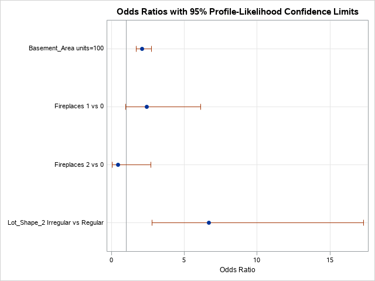

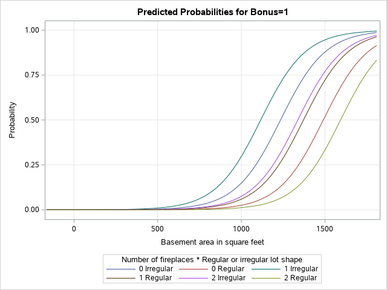

```sas
ods graphics on;
proc logistic data=STAT1.ameshousing3 plots(only)=(effect oddsratio);
    class Fireplaces(ref='0') Lot_Shape_2(ref='Regular') / param=ref;
    model Bonus(event='1')=Basement_Area Fireplaces Lot_Shape_2 / clodds=pl;
    units Basement_Area=100;
    title 'LOGISTIC MODEL (2):Bonus= Basement_Area Fireplaces Lot_Shape_2';
run;
```

In the PROC LOGISTIC statement, we specify the ameshousing3 data, and the PLOTS= option specifies an effect plot and an odds ratio plot. The CLASS statement specifies the categorical predictors Fireplaces and Lot_Shape_2 and the parameterization method. By default, PROC LOGISTIC uses effect coding. To specify reference cell coding, you use the PARAM= option.

As the default reference level for either effect coding or reference cell coding, PROG LOGISTIC uses the last level in alphanumeric order. To specify a reference level, you use the REF= variable option. You can specify the actual value, or level, in quotation marks, or the keyword FIRST or LAST. In this example, Fireplaces has a reference level of 0, and Lot_Shape_2 has a reference level of Regular.

The MODEL statement is the same as the previous demonstration, but it now specifies all three predictor variables.

The UNITS statement enables you to obtain customized odds ratio estimates for a specified unit of change in one or more continuous predictor variables. By default, PROC LOGISTIC finds odds ratios for a one-unit change in the continuous predictors. However, for a variable like Basement_Area, it doesn't make sense to find the odds ratios between two homes where one has only a single square foot larger basement area. Instead, we might want to find the odds ratios for homes with a difference of 100 square feet in basement area, because it's more interpretable. For each continuous predictor, you specify the variable name, an equal sign, and a list of one or more units of change, separated by spaces. In this example, we specify the number 100 as the unit of change for the continuous predictor Basement_Area.

The Class Level Information table includes the predictor variables in the CLASS statement. Because we used the PARAM=REF and REF='Regular' options, this table reflects our choice of Lot_Shape_2='Regular' as the reference level. The design variable is 1 when Lot_Shape_2='Irregular' and 0 when Lot_Shape_2='Regular'. The reference level for Fireplaces is 0, so there are two design variables, each coded 0 for observations where Fireplaces=0.

The SC value in the Basement_Area only model was 169.246. Here in the Fit Statistics table, it's 159.001. Recalling that smaller values imply better fit, you can conclude that this model fits better.

In the Global Tests table, Testing Global Null Hypothesis: Beta=0, we see that this model is statistically significant, indicating at least one of the predictors in the model is significantly different from zero.

The Type 3 Analysis of Effects table is generated when you use the CLASS statement. This table displays the significance of each of the effects individually, adjusting for other predictors included in the model. Fireplaces is not statistically significant at the 0.05 level, but the other remaining predictors are statistically significant. Notice for Fireplaces, there are two degrees of freedom. This is because Fireplaces has three levels and two dummy variables, or effects in the model. This table tests for the significance of Fireplaces, and therefore, tests for the significance of both of its effects jointly. The continuous predictor Basement_Area only has one degree of freedom, and Lot_Shape_2 has two levels, and therefore, only 1 dummy variable and degree of freedom.

Next let's look at the Parameter Estimates table, Analysis of Maximum Likelihood Estimates. For CLASS variables, effects are displayed for each of the design variables. Because reference cell coding was used, each effect is measured against the reference level. For example, the estimate for Lot_Shape_2 | Irregular shows the difference in logits between houses with Irregular and Regular lot shapes, which is 1.9025. Fireplaces | 1 shows the logit difference between houses with 1 fireplace and 0 fireplaces, while Fireplaces | 2 shows the difference in logits between houses with 2 fireplaces and 0 fireplaces. Not all of these effects are statistically significant. Notice that the Wald Chi-Square values and p-values are the same in both tables for Basement_Area and Lot_Shape_2. This is because they only have one degree of freedom. Whereas each effect for Fireplaces is tested separately in this table, so the chi-square values are different than the type 3 analysis of effects.

In the Association of Predicted Probabilities and Observed Responses table, the c statistic value is 0.930, and the percent concordant is approximately 93% for this model, indicating that 93% of the positive and negative response pairs are correctly sorted using Basement_Area, Fireplaces, and Lot_Shape_2.

The Odds Ratio Estimates table shows that, adjusting for other predictor variables, homes with Irregular lots had 6.703 times the odds of being bonus eligible than homes with Regular lots. Homes with 1 fireplace had nearly 2.5 times the odds of being bonus eligible than homes with 0 fireplaces, and homes with 2 fireplaces had less than half the odds than the homes with 0 fireplaces. The table shows that for each 100-square-foot increase in basement area, the bonus eligibility odds increase by 110.5%. Notice that the confidence intervals for the Basement_Area and Lot_Shape_2 odds ratios do not cover a value of 1, indicating the odds ratios are statistically significant for these two variables. However, the odds ratios for Fireplaces both cover 1, and therefore, they are not statistically significant.

The ODDSRATIO plot displays these confidence intervals graphically, and you can see which intervals cover the vertical line at a value of 1.

#### Practice: Using PROC LOGISTIC to Perform a Multiple Logistic Regression Analysis with Categorical Variables

The insurance company wants to model the relationship between three of a car's characteristics, weight, size, and region of manufacture, and its safety rating. The stat1.safety data set contains the data about vehicle safety.

1. Use PROC LOGISTIC to fit a multiple logistic regression model with Unsafe as the response variable and Weight, Size, and Region as the predictor variables. Use the EVENT= option to model the probability of Below Average safety scores. Specify Region and Size as classification variables and use reference cell coding. Specify Asia as the reference level for Region, and 3 (large cars) as the reference level for Size. Request profile likelihood confidence limits, an odds ratio plot, and the effect plot. Submit the code and view the results.

First lets check the data

| Obs | Unsafe | Size | Weight | Region | Type |
| --- | --- | --- | --- | --- | --- |
| 1 | 0 | 2 | 3 | N America | Medium |
| 2 | 0 | 3 | 4 | N America | Sport/Utility |
| 3 | 0 | 2 | 3 | N America | Medium |

LOGISTIC MODEL (2):Unsafe=Weight Region Size

The LOGISTIC Procedure

| Model Information |  |
| --- | --- |
| Data Set | STAT1.SAFETY |
| Response Variable | Unsafe |
| Number of Response Levels | 2 |
| Model | binary logit |
| Optimization Technique | Fisher's scoring |

| Number of Observations Read | 96 |
| --- | --- |
| Number of Observations Used | 96 |

| Response Profile Ordered Value | Response Profile Unsafe | Response Profile Total Frequency |
| --- | --- | --- |
| 1 | 0 | 66 |
| 2 | 1 | 30 |

Probability modeled is Unsafe=1.

| Class Level Information Class | Class Level Information Value | Class Level Information Design Variables | Class Level Information Design Variables |
| --- | --- | --- | --- |
| Region | Asia | 0 |  |
|  | N America | 1 |  |
| Size | 1 | 1 | 0 |
|  | 2 | 0 | 1 |
|  | 3 | 0 | 0 |

| Model Convergence Status |
| --- |
| Convergence criterion (GCONV=1E-8) satisfied. |

| Model Fit Statistics Criterion | Model Fit Statistics Intercept Only | Model Fit Statistics Intercept and Covariates |
| --- | --- | --- |
| AIC | 121.249 | 94.004 |
| SC | 123.813 | 106.826 |
| -2 Log L | 119.249 | 84.004 |

| Testing Global Null Hypothesis: BETA=0 Test | Testing Global Null Hypothesis: BETA=0 Chi-Square | Testing Global Null Hypothesis: BETA=0 DF | Testing Global Null Hypothesis: BETA=0 Pr > ChiSq |
| --- | --- | --- | --- |
| Likelihood Ratio | 35.2441 | 4 | <.0001 |
| Score | 32.8219 | 4 | <.0001 |
| Wald | 23.9864 | 4 | <.0001 |

| Type 3 Analysis of Effects Effect | Type 3 Analysis of Effects DF | Type 3 Analysis of Effects Wald Chi-Square | Type 3 Analysis of Effects Pr > ChiSq |
| --- | --- | --- | --- |
| Weight | 1 | 2.1176 | 0.1456 |
| Region | 1 | 0.4506 | 0.5020 |
| Size | 2 | 15.3370 | 0.0005 |

| Analysis of Maximum Likelihood Estimates Parameter | Analysis of Maximum Likelihood Estimates | Analysis of Maximum Likelihood Estimates DF | Analysis of Maximum Likelihood Estimates Estimate | Analysis of Maximum Likelihood Estimates Standard Error | Analysis of Maximum Likelihood Estimates Wald Chi-Square | Analysis of Maximum Likelihood Estimates Pr > ChiSq |
| --- | --- | --- | --- | --- | --- | --- |
| Intercept |  | 1 | 0.0500 | 1.8008 | 0.0008 | 0.9778 |
| Weight |  | 1 | -0.6678 | 0.4589 | 2.1176 | 0.1456 |
| Region | N America | 1 | -0.3775 | 0.5624 | 0.4506 | 0.5020 |
| Size | 1 | 1 | 2.6783 | 0.8810 | 9.2422 | 0.0024 |
| Size | 2 | 1 | 0.6582 | 0.9231 | 0.5085 | 0.4758 |

| Association of Predicted Probabilities and Observed Responses |  |  |  |
| --- | --- | --- | --- |
| Percent Concordant | 81.9 | Somers' D | 0.696 |
| Percent Discordant | 12.3 | Gamma | 0.739 |
| Percent Tied | 5.8 | Tau-a | 0.302 |
| Pairs | 1980 | c | 0.848 |

| Odds Ratio Estimates and Profile-Likelihood Confidence Intervals Effect | Odds Ratio Estimates and Profile-Likelihood Confidence Intervals Unit | Odds Ratio Estimates and Profile-Likelihood Confidence Intervals Estimate | Odds Ratio Estimates and Profile-Likelihood Confidence Intervals 95% Confidence Limits | Odds Ratio Estimates and Profile-Likelihood Confidence Intervals 95% Confidence Limits |
| --- | --- | --- | --- | --- |
| Weight | 1.0000 | 0.513 | 0.201 | 1.260 |
| Region N America vs Asia | 1.0000 | 0.686 | 0.225 | 2.081 |
| Size 1 vs 3 | 1.0000 | 14.560 | 3.018 | 110.732 |
| Size 2 vs 3 | 1.0000 | 1.931 | 0.343 | 15.182 |

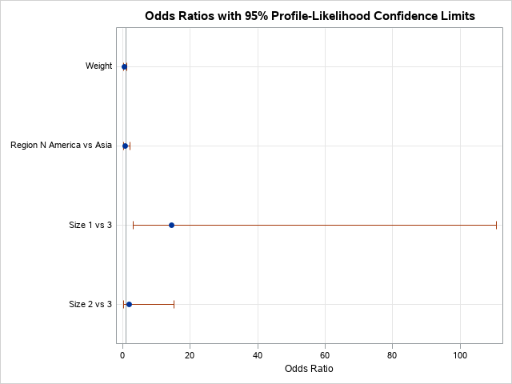

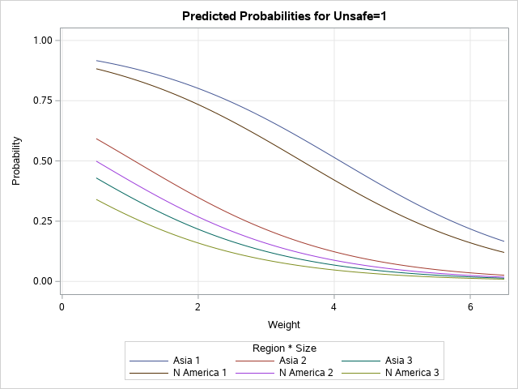

```sas
title 'First lets check the data';
proc print data=STAT1.safety(obs=3);
run;
title;

ods graphics on;
proc logistic data=STAT1.safety plots(only)=(effect oddsratio);
   class Region (param=ref ref='Asia')
         Size (param=ref ref='3');
   model Unsafe(event='1')=Weight Region Size / clodds=pl;
   title 'LOGISTIC MODEL (2):Unsafe=Weight Region Size';
run;
```

1. Do you reject or fail to reject the null hypothesis that all regression coefficients of the model are 0?

Solution: The p-value for the Likelihood Ratio test is <.0001, and therefore, you reject the null hypothesis.

1. If you reject the global null hypothesis, then which predictors significantly predict safety outcome?

Solution: Only Size is significantly predictive of Unsafe.

1. Interpret the odds ratio for significant predictors.

Solution: Only Size is significant. The design variables show that Size=1 (Small or Sports) cars have 14.560 times the odds of having a Below Average safety rating compared to the reference category 3 (Large or Sport/Utility). The 95% confidence interval (3.018, 110.732) does not contain 1, implying that the contrast is statistically significant at the 0.05 level.

The contrast from the second design variable is 1.931 (Medium versus Sport/Utility), implying a trend toward greater odds of low safety as size decreases. However, the 95% confidence interval (0.343, 15.182) contains 1, and therefore, the contrast is not statistically significant.

#### Stepwise Selection with Interactions and Predictions